# Lecture 13 Notes – Differential gene expression analysis

In lecture we’ll follow a traditional workflow, where we align RNA-seq reads to a reference genome, allowing for gaps from RNA splicing, then convert the BAM files to a count matrix for differential expression analysis. In lab we’ll use a newer approach for differential expression analysis.

## Building the Bowtie2 index

The index allows the aligner to very quickly find places that a read might match the reference genome. We only have to build the index once. This is done at the Linux terminal or in a bash script.

```
bowtie2-build Osativa_323_v7.0.hardmasked.fa Osativa_323_v7.0.hardmasked
```

## Aligning with TopHat

I wrote a bash script to do all of the alignments on Biocluster. The reference genome FASTA, Bowtie2 index, and all FASTQ files were in the same folder as this script.

```bash
#!/bin/bash

module load TopHat

for i in 49 50 51 52 53 54 55 56 57
do
tophat -o ./DRR0003${i}_tophat Osativa_323_v7.0.hardmasked DRR0003${i}.fastq
done
```

This created a folder for each FASTQ file containing alignment information and possible intron-exon junctions. The file `accepted_hits.bam` in each folder contained the actual alignment data. I downloaded just these BAM files and renamed them according to the run name.

## Previewing BAM files

Now on our Ubuntu virtual machines, we can use SAMtools to take a look at the files. We’ll use `samtools view` to convert binary format back to text format, then pipe the results to `head` to just see the beginning.

```
samtools view /media/sf_ricedata/DRR000351.bam | head
```

## Loading the BAM files into Bioconductor

Here are the packages we’ll need today:

```r
# From Bioconductor
library(GenomicFeatures)
library(Rsamtools)
library(GenomicAlignments)
library(DESeq2)
library(BiocParallel)
library(apeglm)

# From CRAN
library(ggplot2)
library(ggbeeswarm)
library(pheatmap)

# change parallel processing parameters to keep summarizeOverlaps from freezing
register(SnowParam(workers = 1))
```

We’ll load in the gene annotation data for rice into a `TxDb` object. Then we’ll point R to our BAM files and count the reads per gene.

```r
# Get annotation data
riceTxDb <- makeTxDbFromGFF("Osativa_323_v7.0.gene.gff3.gz",
                            "gff3", dataSource = "Phytozome 12", organism = "Oryza sativa")
```

```
## Import genomic features from the file as a GRanges object ... OK
## Prepare the 'metadata' data frame ... OK
## Make the TxDb object ... OK
```

```r
exonsByGene <- exonsBy(riceTxDb, "gene")

# Get BAM files
riceBamPaths <- paste("TophatSAM/DRR0003", 49:57, ".bam", sep = "")
riceBam <- BamFileList(riceBamPaths)
```

```r
# Count reads per gene -- takes a few minutes
riceCounts <- summarizeOverlaps(exonsByGene, riceBam, singleEnd = TRUE,
                                ignore.strand = TRUE)
save(riceCounts, file = "riceCounts.RData")
```

Since `summarizeOverlaps` takes a while to process, I saved the output.

```r
load("riceCounts.RData")
```

Our `riceCounts` object is of the class `RangedSummarizedExperiment`. The `SummarizedExperiment` class is designed to hold matrices of numeric data, with assays in rows and samples in columns. The `RangedSummarizedExperiment` extends that a little further by associating a genomic range with each assay. In this case each assay is a gene, and the numeric data is the number of aligned reads overlapping exons of that gene.

```r
riceCounts
```

```
## class: RangedSummarizedExperiment
## dim: 42189 9
## metadata(0):
## assays(1): counts
## rownames(42189): ChrSy.fgenesh.gene.1 ChrSy.fgenesh.gene.10 ...
##   LOC_Os12g44380 LOC_Os12g44390
## rowData names(0):
## colnames(9): DRR000349.bam DRR000350.bam ... DRR000356.bam
##   DRR000357.bam
## colData names(0):
```

```r
assay(riceCounts)[1:5,]
```

```
##                       DRR000349.bam DRR000350.bam DRR000351.bam
## ChrSy.fgenesh.gene.1              0             0             0
## ChrSy.fgenesh.gene.10             0             0             0
## ChrSy.fgenesh.gene.11             0             0             0
## ChrSy.fgenesh.gene.12             0             0             0
## ChrSy.fgenesh.gene.13             0             0             0
##                       DRR000352.bam DRR000353.bam DRR000354.bam
## ChrSy.fgenesh.gene.1              0             0             0
## ChrSy.fgenesh.gene.10             0             0             0
## ChrSy.fgenesh.gene.11             0             0             0
## ChrSy.fgenesh.gene.12             0             0             0
## ChrSy.fgenesh.gene.13             0             0             0
##                       DRR000355.bam DRR000356.bam DRR000357.bam
## ChrSy.fgenesh.gene.1              0             0             0
## ChrSy.fgenesh.gene.10             0             0             0
## ChrSy.fgenesh.gene.11             0             0             0
## ChrSy.fgenesh.gene.12             0             0             0
## ChrSy.fgenesh.gene.13             0             0             1
```

```r
rowRanges(riceCounts)
```

```
## GRangesList object of length 42189:
## $ChrSy.fgenesh.gene.1
## GRanges object with 1 range and 2 metadata columns:
##       seqnames    ranges strand |   exon_id
##          <Rle> <IRanges>  <Rle> | <integer>
##   [1]    ChrSy  785-1168      - |    239016
##                                exon_name
##                              <character>
##   [1] ChrSy.fgenesh.mRNA.1.MSUv7.0.CDS.1
##
## $ChrSy.fgenesh.gene.10
## GRanges object with 3 ranges and 2 metadata columns:
##       seqnames      ranges strand | exon_id
##   [1]    ChrSy 48848-49897      - |  239026
##   [2]    ChrSy 50269-50676      - |  239027
##   [3]    ChrSy 50779-51012      - |  239028
##                                 exon_name
##   [1] ChrSy.fgenesh.mRNA.10.MSUv7.0.CDS.3
##   [2] ChrSy.fgenesh.mRNA.10.MSUv7.0.CDS.2
##   [3] ChrSy.fgenesh.mRNA.10.MSUv7.0.CDS.1
##
## $ChrSy.fgenesh.gene.11
## GRanges object with 1 range and 2 metadata columns:
##       seqnames      ranges strand | exon_id
##   [1]    ChrSy 53593-53841      - |  239029
##                                 exon_name
##   [1] ChrSy.fgenesh.mRNA.11.MSUv7.0.CDS.1
##
## ...
## <42186 more elements>
## -------
## seqinfo: 14 sequences from an unspecified genome; no seqlengths
```

We need to set up a table of sample information.

```r
rice_sam <- data.frame(row.names = paste("DRR0003", 49:57, sep = ""),
                       tissue = c("root", "shoot")[c(2,1,2,1,2,1,2,1,1)],
                       treatment = c("control", "salinity_stress")[c(1,1,2,2,1,1,2,2,2)],
                       run = paste("DRR0003", 49:57, sep = ""))
rice_sam
```

```
##           tissue       treatment       run
## DRR000349  shoot         control DRR000349
## DRR000350   root         control DRR000350
## DRR000351  shoot salinity_stress DRR000351
## DRR000352   root salinity_stress DRR000352
## DRR000353  shoot         control DRR000353
## DRR000354   root         control DRR000354
## DRR000355  shoot salinity_stress DRR000355
## DRR000356   root salinity_stress DRR000356
## DRR000357   root salinity_stress DRR000357
```

In the Bioconductor documentation you’ll see a note about using `relevel` on the factor representing your treatment, to make sure the first level is the control group and the second level is the treatment group. In this case, we don’t have to do that since “control” comes before “salinity_stress” in the alphabet.

We’ll add that sample data to our object, then build the `DESeqDataSet` object. Note that the `DESeqDataSet` object contains a formula, like one that you would use for linear regression, indicating how the experiment was set up. The variable of interest should always be the last one in the formula.

```r
# add sample data to the counts object
colData(riceCounts) <- DataFrame(rice_sam)

# make DESeq2 dataset
riceDESeq <- DESeqDataSet(riceCounts, design = ~ tissue + treatment)

# filter out low read depth genes
riceDESeq <- riceDESeq[rowSums(counts(riceDESeq)) > 1, ]
```

## Confirming similarity between samples

Before we analyze the data, we might want to get a quick visualization. The `rlog` function normalizes the samples by total depth and does a log transformation.

```r
# normalize for visualization
riceDESeqRlog <- rlog(riceDESeq, blind = FALSE)

# get a heat map of samples
riceDist <- as.matrix(dist(t(assay(riceDESeqRlog))))
riceDist
```

```
##           DRR000349 DRR000350 DRR000351 DRR000352 DRR000353 DRR000354
## DRR000349   0.00000 380.45586 109.56671 392.17522  80.01338 383.79644
## DRR000350 380.45586   0.00000 383.10580 149.89784 379.90364  81.69826
## DRR000351 109.56671 383.10580   0.00000 384.13614 110.83572 386.49323
## DRR000352 392.17522 149.89784 384.13614   0.00000 392.27746 147.65771
## DRR000353  80.01338 379.90364 110.83572 392.27746   0.00000 383.75856
## DRR000354 383.79644  81.69826 386.49323 147.65771 383.75856   0.00000
## DRR000355 112.08873 382.82193  82.96605 384.62963 111.04427 386.96226
## DRR000356 393.11161 149.00175 385.13880  90.62352 392.34738 149.67218
## DRR000357 399.36015 157.69921 391.39737  88.86172 401.07324 150.84517
##           DRR000355 DRR000356 DRR000357
## DRR000349 112.08873 393.11161 399.36015
## DRR000350 382.82193 149.00175 157.69921
## DRR000351  82.96605 385.13880 391.39737
## DRR000352 384.62963  90.62352  88.86172
## DRR000353 111.04427 392.34738 401.07324
## DRR000354 386.96226 149.67218 150.84517
## DRR000355   0.00000 384.31332 393.22065
## DRR000356 384.31332   0.00000 102.54853
## DRR000357 393.22065 102.54853   0.00000
```

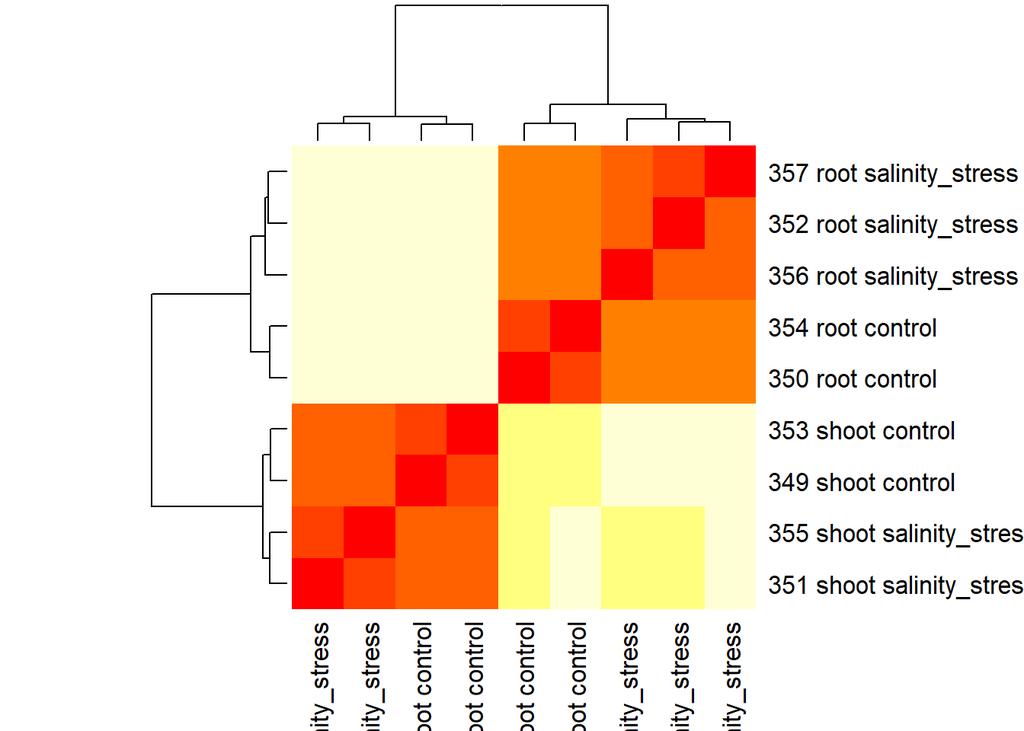

```r
newNames <- paste(349:357, rice_sam$tissue, rice_sam$treatment)
rownames(riceDist) <- newNames
colnames(riceDist) <- newNames
heatmap(riceDist)
```

We can see that the samples are grouped fairly tightly, first by tissue, then by treatment. If this wasn’t the case, we might want to confirm that we hadn’t mixed up the BAM files.

## Running the analysis

Now we can find genes that are differentially expressed a statistically significant amount.

```r
# run the model
riceDESeq <- DESeq(riceDESeq)

# look at results with LFC threshold of one
riceResults <- results(riceDESeq, lfcThreshold = 1)
summary(riceResults)
```

```
##
## out of 31952 with nonzero total read count
## adjusted p-value < 0.1
## LFC > 1.00 (up)    : 226, 0.71%
## LFC < -1.00 (down) : 29, 0.091%
## outliers [1]       : 0, 0%
## low counts [2]     : 3717, 12%
## (mean count < 1)
## [1] see 'cooksCutoff' argument of ?results
## [2] see 'independentFiltering' argument of ?results
```

```r
# find interesting genes
interestingGenes <- row.names(riceResults)[which((riceResults$log2FoldChange > 1 |
                                                   riceResults$log2FoldChange < -1) &
                                                   riceResults$padj < 0.05)]
# sort them so most significant are first
interestingGenes <- interestingGenes[order(riceResults[interestingGenes, "padj"])]

str(interestingGenes)
```

```
##  chr [1:223] "LOC_Os03g09170" "LOC_Os09g33640" "LOC_Os09g28210" ...
```

## Visualizing how the significant hits were identified

Well make an MA-plot to look at the log-fold change versus the read depth, with significant hits highlighted using color. First we have to apply shrinkage to the dataset, since very low depth genes will have high sampling error, and could appear to have a high log-fold change without being significant.

```r
shrunk <- lfcShrink(riceDESeq,
                    coef="treatment_salinity_stress_vs_control", type="apeglm")
```

Now we make the plot.

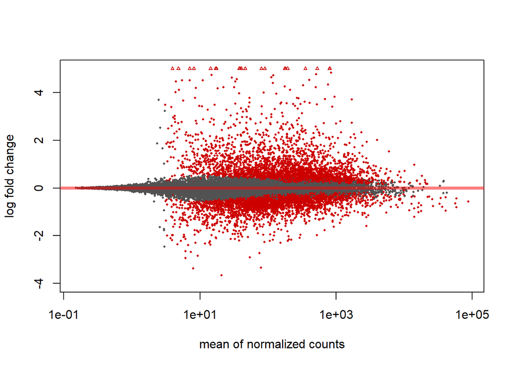

```r
plotMA(shrunk, ylim = c(-4, 5))
```

One thing to notice here is that we have some very highly upregulated genes under salt stress. We have downregulated genes too, but not quite as much. (This is why it is important to put the control as the first level in the treatment factor, so we know which in direction the change is happening.)

## Visualizing expression changes in individual genes

For the top hits, how much did expression change? In which direction? And was it consistent across tissues? The `plotCounts` function can tell us, and moreover it can (optionally) be integrated with `ggplot2`.

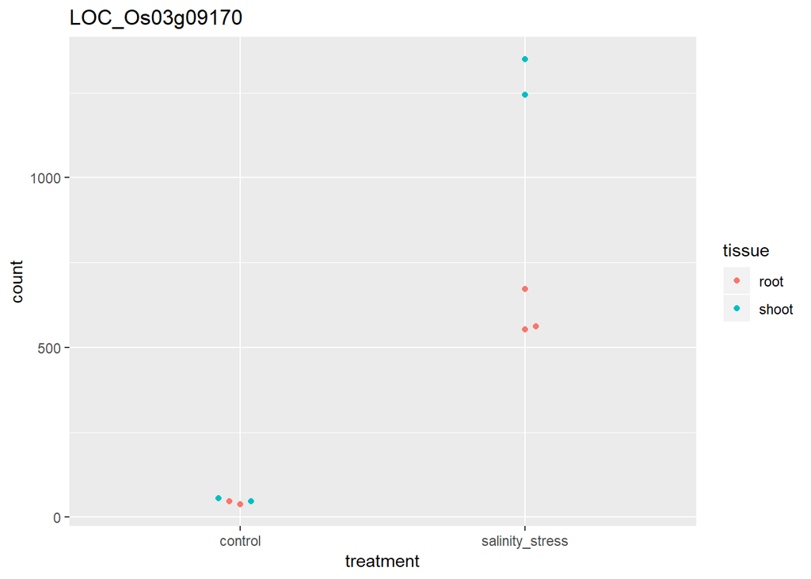

```r
# plot the most significant gene
plot1 <- plotCounts(riceDESeq, interestingGenes[1], intgroup = c("treatment", "tissue"),
                    returnData = TRUE)

ggplot(plot1, aes(x = treatment, y = count, col = tissue)) +
  geom_beeswarm(cex = 2) +
  ggtitle(interestingGenes[1])
```

## Gene annotations for the top hits

What do these genes actually do? We can look them up in our defline table.

```r
# get gene annotations
riceDefline <- read.delim("Osativa_323_v7.0.defline.txt",
                          header = FALSE, row.names = 1,
                          stringsAsFactors = FALSE)
riceDefline[interestingGenes[1:20],2]
```

```
##  [1] "ethylene-responsive transcription factor, putative, expressed"
##  [2] "expressed protein"
##  [3] "bHelix-loop-helix transcription factor, putative, expressed"
##  [4] "expressed protein"
##  [5] "9-cis-epoxycarotenoid dioxygenase 1, chloroplast precursor, putative, expressed"
##  [6] "expressed protein"
##  [7] "helix-loop-helix DNA-binding domain containing protein, expressed"
##  [8] "homeobox associated leucine zipper, putative, expressed"
##  [9] "EF hand family protein, putative, expressed"
## [10] "pectinesterase, putative, expressed"
## [11] "STE_MEKK_ste11_MAP3K.7 - STE kinases include homologs to sterile 7, sterile 11 and sterile 20 from yeast, expressed"
## [12] "WRKY108, expressed"
## [13] "STE_MEKK_ste11_MAP3K.5 - STE kinases include homologs to sterile 7, sterile 11 and sterile 20 from yeast, expressed"
## [14] "enzyme of the cupin superfamily protein, putative, expressed"
## [15] NA
## [16] "aluminum-activated malate transporter, putative, expressed"
## [17] "OsWAK125 - OsWAK receptor-like protein OsWAK-RLP, expressed"
## [18] "helix-loop-helix DNA-binding domain containing protein, expressed"
## [19] NA
## [20] "MATE domain containing protein, expressed"
```

The top hit is a transcription factor that responds to ethylene, and ethylene is known to be involved in responses to salt stress (see https://www.ncbi.nlm.nih.gov/pmc/articles/PMC4661241/). So that’s a promising sign for the results being meaningful! Several of the other top hits are involved in gene expression regulation and cellular signalling.

## Visualizing and grouping all the top hits

Now that we have it narrowed down to a smaller group of genes that we are interested in, we can do a heat map to look at expression patterns of those genes.

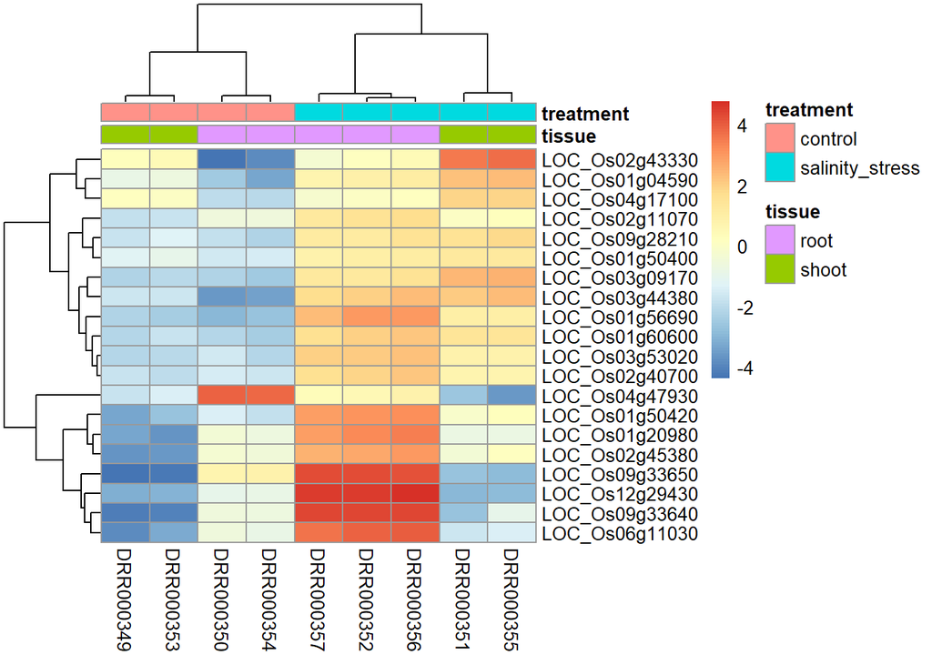

```r
to_plot <- assay(riceDESeqRlog[interestingGenes[1:20], ])

to_plot <- to_plot - rowMeans(to_plot) # center each gene

pheatmap(to_plot, annotation_col = rice_sam[,c("tissue", "treatment")])
```

The two main groups of genes seem to be those just upregulated in the roots, and those upregulated in both tissues.